# Patrones Puntuales

María Paula Camargo Rincón Laura Katherine Martinez Castiblanco

# 1 Introducción

Un patrón puntual espacial se define como un conjunto de ubicaciones observadas ,los denominados eventos, que no han sido fijos ni predeterminados por ningún diseño de muestreo, sino que emergen de forma natural o como resultado de procesos subyacentes. El análisis de estos patrones resulta fundamental para desentrañar los mecanismos que generan dicha distribución espacial, ya que permite ir más allá de la simple descripción geográfica y adentrarse en la comprensión causal de los fenómenos. Esta aproximación tiene aplicaciones en muy diversos campos: desde el estudio de la dispersión de especies y la dinámica de poblaciones, hasta el análisis de la movilidad laboral, la localización de actividades económicas o incluso la prevención de accidentes aéreos. En todos estos casos, entender cómo y por qué se agrupan, dispersan o aleatorizan los eventos en el espacio ofrece claves valiosas para la toma de decisiones y la formulación de hipótesis científicas.

# 2 Aplicación Práctica en R: Análisis de Patrones Puntuales de Sismicidad en Colombia

“*Un sismo es la liberación de energía elástica almacenada durante años por movimientos relativos entre placas tectónicas*” Carrillo, Bernal, and Porras (2013).

El interés de estudiar estos eventos radica en que pueda generar consecuencias que afectan varios ámbitos de nuestro país.

La base de datos utilizada recopila información sobre sismos con magnitud igual o superior a 4.5.

Para iniciar un ejercicio de **patrones puntuales** siguiendo la metodología de la Dra. Martha Bohórquez (Bohorquez (2026)), el primer paso fundamental es preparar el entorno con las librerías especializadas y transformar los datos tabulares (como los de Excel) en objetos espaciales que R pueda procesar.

A continuación, se presenta el código inicial estructurado para instalar las herramientas necesarias, cargar los datos de los epicentros y crear un objeto de patrón puntual (`ppp`).

### 2.0.1 1. Instalación y Carga de Librerías

Para el análisis de patrones puntuales, la librería principal es **`spatstat`**. Adicionalmente, utilizaremos **`sf`** para el manejo moderno de datos espaciales y **`readxl`** para importar desde Excel.

```r
# Instalación de paquetes si no están presentes
if(!require(spatstat)) install.packages("spatstat")
if(!require(spatstat)) install.packages("spatstat.explore")
if(!require(spatstat)) install.packages("spatstat.model")
if(!require(sf)) install.packages("sf")
if(!require(readxl)) install.packages("readxl")
if(!require(tidyverse)) install.packages("tidyverse")
# Instalar el paquete de datos explícitamente con dependencias
if(!require(rnaturalearthdata)) install.packages("rnaturalearthdata",
                 dependencies = TRUE,
                 type = "binary")  # Usa binarios precompilados en Windows

# Carga de librerías
library(spatstat)  # Análisis de patrones puntuales
library(sf)        # Manejo de datos vectoriales
library(readxl)    # Lectura de archivos Excel
library(tidyverse) # Manipulación de datos
library(ggplot2)      # Visualización
library(dplyr)        # Manipulación de datos
library(readr)        # Lectura de CSV
library(rnaturalearth) # Descarga automática de mapas mundiales
library(scales)       # Para formato de ejes en gráficos
library(patchwork)    # Poner gráficos lado a lado
library(knitr)
library(kableExtra)
library(stars)        # Esencial para convertir mapas de spatstat a ggplot2
library(ggrepel)      # Crucial para que los IDs no se tapen entre sí
library(spatstat.geom)
library(spatstat.explore)
library(corrplot)
```

### 2.0.2 2. Carga y Preparación de Datos

Dado que los datos de epicentros suelen venir en coordenadas geográficas (latitud/longitud), es una buena práctica convertirlos a un sistema proyectado (en metros) para que los cálculos de distancias e intensidades sean precisos.

```r
# ==============================================================================
#  OBTENER SHAPEFILE DE COLOMBIA (Automático, sin descarga manual)
# rnaturalearth descarga límites administrativos de Natural Earth (dominio público)
# scale = "medium" ofrece buen equilibrio entre detalle y velocidad
# Cargar mapa de Colombia (sf)
colombia_map <- rnaturalearth::ne_countries(scale = "medium", country = "colombia", returnclass = "sf")

# Proyectar a CRS adecuado para visualización en Colombia (WGS84 es suficiente para puntos)
colombia_map <- st_transform(colombia_map, crs = 4326)


# Cargar TODOS los países de Sudamérica para ver los vecinos colindantes
paises_vecinos <- ne_countries(scale = "medium", returnclass = "sf")
paises_vecinos <- st_transform(paises_vecinos, crs = 4326)

# ==============================================================================
# . CARGAR Y LIMPIAR DATOS DE SISMICIDAD (SGC)
# Leer CSV saltando las 7 filas de encabezado institucional
df <- read_csv("sismicidad_historica.csv", skip = 7, show_col_types = FALSE)

# Renombrar columnas clave para trabajar más fácil
names(df)[4] <- "Latitud"
names(df)[5] <- "Longitud"
names(df)[7] <- "magnitudd"

# Convertir a numérico de forma segura (maneja caracteres no numéricos como NA)
df <- df %>% select(Latitud, Longitud, magnitudd) %>%
  mutate(
    Latitud   = as.numeric(Latitud),
    Longitud  = as.numeric(Longitud),
    magnitudd  = as.numeric(magnitudd)
  )

# Filtrar filas con coordenadas inválidas (evita errores en st_as_sf)
#df <- df %>% filter(!is.na(Latitud) & !is.na(Longitud))
summary(df)
```

```
##     Latitud          Longitud        magnitudd
##  Min.   : 0.530   Min.   :-81.52   Min.   :4.500
##  1st Qu.: 2.466   1st Qu.:-77.31   1st Qu.:5.900
##  Median : 4.570   Median :-75.67   Median :6.200
##  Mean   : 4.774   Mean   :-75.65   Mean   :6.283
##  3rd Qu.: 6.912   3rd Qu.:-73.83   3rd Qu.:6.625
##  Max.   :12.610   Max.   :-71.08   Max.   :8.800
```

```r
# ==============================================================================
#  CONVERTIR DATAFRAME A OBJETO ESPACIAL (sf)
# st_as_sf() convierte el dataframe en puntos georreferenciados
# crs = 4326 = WGS84 (lat/lon en grados decimales, estándar GPS)

# Proyección de Coordenadas (De Grados a Metros)
# Es vital para que la Función K sea en metros/km y no en grados
sismos_sf <- st_as_sf(df, coords = c("Longitud", "Latitud"), crs = 4326)

# Añadimos una columna explícita con el ID a sf de sismos
sismos_sf$ID_Sismo <- 1:nrow(sismos_sf)

# transformar las coordenadas geográficas de los sismos en Colombia de grados a metros, utilizando el sistema de proyección oficial del país.
# Transforma matemáticamente la curvatura de la Tierra a un plano bidimensional (proyección).
sismos_proj <- st_transform(sismos_sf, crs = 9377)





## Ventana de Visualización (Bounding Box)

# Basado en el recuadro visual de la plataforma del SGC:
# Longitudes aproximadas: -84°W a -65°W | Latitudes aproximadas: -4.5°S a 13.5°N
limites_grados <- st_bbox(c(xmin = -84, ymin = -4.5, xmax = -65, ymax = 13.5),
                          crs = st_crs(4326))

# Convertimos este recuadro en un polígono sf para poder proyectarlo correctamente
ventana_sf <- st_as_sfc(limites_grados)

# Proyectamos también nuestra ventana rectangular a metros
ventana_proj <- st_transform(ventana_sf, crs = 9377)
bbox_metros  <- st_bbox(ventana_proj)






# ==============================================================================
# 3. FILTRADO GEOGRÁFICO AJUSTADO (ELIMINA EL PUNTO EXTREMO NOROESTE)
# ==============================================================================
# 🛠️ CORRECCIÓN: Cambiamos xmin a -79.5 para dejar fuera el sismo de San Andrés
# pero manteniendo ymin = 0 para salvar todo el sur del país.
caja_filtro <- st_bbox(c(xmin = -79.5, ymin = 0, xmax = -66, ymax = 13.5), crs = 4326)

sismos_sf <- sismos_sf %>%
  st_filter(st_as_sfc(caja_filtro))

# Proyectamos los sismos limpios a metros (Origen Nacional CRS 9377)
sismos_proj <- st_transform(sismos_sf, crs = 9377)

# ==============================================================================
# 4. CREACIÓN DE LA VENTANA CON MARGEN DE AMORTIGUAMIENTO (BUFFER)
# ==============================================================================
# A. Calculamos la envolvente convexa ajustada en metros
ventana_base_metros <- st_convex_hull(st_union(sismos_proj))

# B. 🛠️ MEJORA: Expandimos la ventana 30 km hacia afuera para que no toque los puntos
ventana_sf <- st_buffer(ventana_base_metros, dist = 30000) # 30,000 metros = 30 Km

# C. Convertimos a formato owin para tus futuros análisis de spatstat
ventana_owin <- as.owin(st_geometry(ventana_sf))

# D. Pasamos la ventana expandida a grados exclusivamente para que ggplot pueda dibujarla
ventana_grados <- st_transform(ventana_sf, crs = 4326)
```

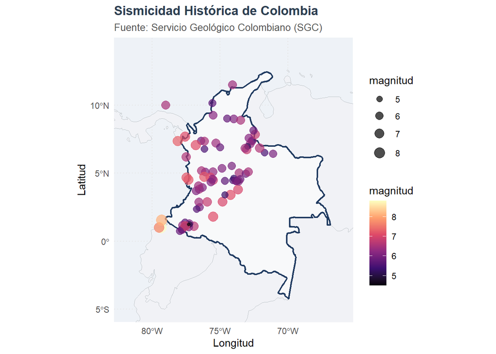

```r
# ==============================================================================
#  VISUALIZACIÓN CON GGPlot2 (Mapa profesional)
ggplot() +
  # Capa 1: Países vecinos (Fondo gris neutro y bordes sutiles)
  geom_sf(data = paises_vecinos,
          fill = "#f1f2f6",
          color = "#bdc3c7",
          linewidth = 0.3) +

  # Capa 2: Resaltar la frontera de Colombia (Línea más gruesa y azul oscuro)
  geom_sf(data = colombia_map,
          fill = "#f8f9fa",         # Un gris más limpio para diferenciarlo de los vecinos
          color = "#1f3a60",        # Tu azul oscuro elegante original
          linewidth = 0.8) +

  # Capa 4: Los sismos puros (Puntos rojos translúcidos)
geom_sf(data = sismos_sf,
          aes(color = magnitudd, size = magnitudd),
          shape = 20,                             # Círculo sólido
          alpha = 0.7) +

  # Escala de colores: Paleta Magma (Amarillo = Alto, Negro/Morado = Bajo)
  scale_color_viridis_c(option = "magma",
                        name = "magnitud") +

  # Escala de tamaño: Los sismos más fuertes se ven más grandes en el mapa
  scale_size_continuous(range = c(2, 8),
                        name = "magnitud") +

  # AJUSTE CRUCIAL: El zoom se abre un poco más (de -86 a -63) para poder ver la ventana flotando
  coord_sf(crs = st_crs(4326),
           xlim = c(-82, -66),
           ylim = c(-5, 14)) +

  # Etiquetas y títulos adaptados
  labs(title = "Sismicidad Histórica de Colombia",
       subtitle = "Fuente: Servicio Geológico Colombiano (SGC)",
       x = "Longitud",
       y = "Latitud") +

  # Estética profesional de fondo de océano
  theme_minimal() +
  theme(
    panel.grid.major = element_line(color = "gray90", linetype = "dotted"),
    plot.title = element_text(face = "bold", size = 13, color = "#2c3e50"),
    plot.subtitle = element_text(size = 10, italic = TRUE, color = "#555555"),
    panel.background = element_rect(fill = "#eef2f7", color = NA) # Océano azul claro
  )
```

### 2.0.3 3. Creación del Patrón Puntual (`ppp`)

Un patrón puntual espacial consiste en un conjunto de ubicaciones llamadas **eventos**. Para usar `spatstat`, debemos extraer las coordenadas y definir una **ventana de observación** (`owin`), que delimita el área donde el fenómeno es posible.

Para trabajar exactamente con la ventana de visualización que presenta el Servicio Geológico Colombiano (SGC) en su plataforma interactiva (la cual incluye sismos en el océano Pacífico, el mar Caribe y zonas fronterizas).

```r
# ==============================================================================
# 5. CONSTRUCCIÓN DEL OBJETO PPP EN KILÓMETROS
# ==============================================================================
coords_metros <- st_coordinates(sismos_proj)

sismos_ppp <- ppp(x = coords_metros[,1],
                  y = coords_metros[,2],
                  window = ventana_owin,
                  marks = sismos_proj$magnitudd)

set.seed(5869)
if(any(duplicated(sismos_ppp))) {
  sismos_ppp <- rjitter(sismos_ppp, retry = TRUE)
}

# Escalamos el objeto final a kilómetros para el informe
sismos_ppp <- spatstat.geom::rescale(sismos_ppp, 1000, "km")
```

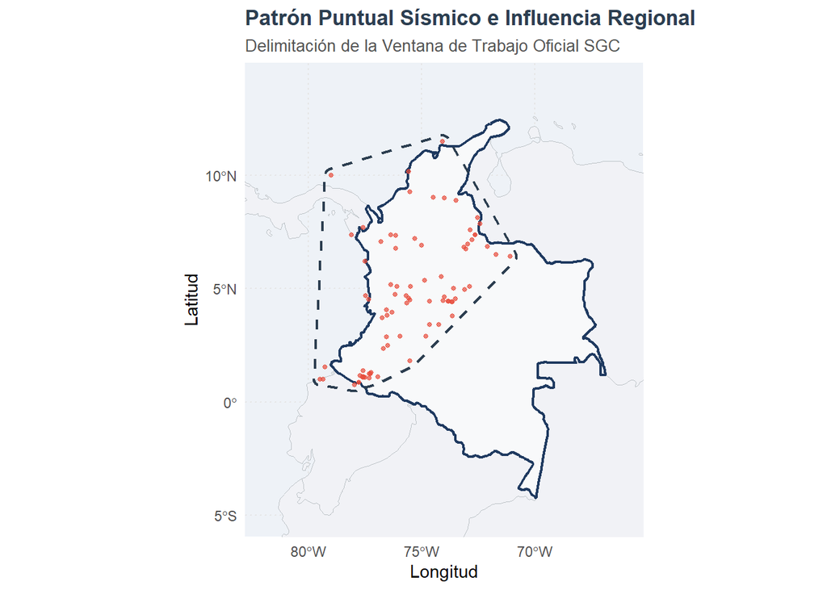

Figure 2.2: Patrón puntual sísmico

```r
ggplot() +
  # Capa 1: Países vecinos (Fondo gris neutro y bordes sutiles)
  geom_sf(data = paises_vecinos,
          fill = "#f1f2f6",
          color = "#bdc3c7",
          linewidth = 0.3) +

  # Capa 2: Resaltar la frontera de Colombia (Línea más gruesa y azul oscuro)
  geom_sf(data = colombia_map,
          fill = "#f8f9fa",         # Un gris más limpio para diferenciarlo de los vecinos
          color = "#1f3a60",        # Tu azul oscuro elegante original
          linewidth = 0.8) +

  # Capa 3: Delimitación de la Ventana de Trabajo del SGC (Línea discontinua roja o negra)
  geom_sf(data = ventana_sf,
          fill = NA,                # Totalmente transparente por dentro
          color = "#2c3e50",        # Color del marco
          linewidth = 0.8,
          style = "dashed",         # Línea discontinua tipo 'mira cartográfica'
          linetype = "dashed") +

  # Capa 4: Los sismos puros (Puntos rojos translúcidos)
  geom_sf(data = sismos_sf,
          color = "#e74c3c",
          size = 1,
          alpha = 0.7) +

  # AJUSTE CRUCIAL: El zoom se abre un poco más (de -86 a -63) para poder ver la ventana flotando
  coord_sf(crs = st_crs(4326),
           xlim = c(-82, -66),
           ylim = c(-5, 14)) +

  # Etiquetas y títulos adaptados
  labs(title = "Patrón Puntual Sísmico e Influencia Regional",
       subtitle = "Delimitación de la Ventana de Trabajo Oficial SGC",
       x = "Longitud", y = "Latitud") +

  # Estética profesional de fondo de océano
  theme_minimal() +
  theme(
    panel.grid.major = element_line(color = "gray90", linetype = "dotted"),
    plot.title = element_text(face = "bold", size = 13, color = "#2c3e50"),
    plot.subtitle = element_text(size = 10, italic = TRUE, color = "#555555"),
    panel.background = element_rect(fill = "#eef2f7", color = NA) # Océano azul claro
  )
```

```r
summary(sismos_ppp)
```

```
## Marked planar point pattern:  81 points
## Average intensity 9.674586e-05 points per square km
##
## Coordinates are given to 12 decimal places
##
## marks are numeric, of type 'double'
## Summary:
##    Min. 1st Qu.  Median    Mean 3rd Qu.    Max.
##   4.500   5.900   6.200   6.281   6.600   8.800
##
## Window: polygonal boundary
## single connected closed polygon with 127 vertices
## enclosing rectangle: [4246.67, 5242.269] x [1612.0024, 2857.9119] km
##                      (995.6 x 1246 km)
## Window area = 837245 square km
## Unit of length: 1 km
## Fraction of frame area: 0.675
```

En la figura 2.2 se presenta la ventana de observación utilizada para el análisis. Esta fue definida excluyendo áreas extensas sin registros relevantes sísmicos, está delimitación evita que grandes zonas vacías influyan en la estimación de características del proceso puntual, como por ejemplo la intensidad.

### 2.0.4 prueba chi cuadrado

Para evaluar si la distribución espacial de la sismicidad en la región de estudio responde a un proceso homogéneo de Aleatoriedad Espacial Completa (CSR), se aplicó una prueba estadística de bondad de ajuste basada en la distribución Chi-cuadrado ($\chi^2$) utilizando una partición del espacio en una rejilla regular de $3 \times 3$ cuadrantes disjuntos.

#### 2.0.4.1 1. Formulación de Hipótesis Estadísticas

- Hipótesis Nula ($H_0$): El patrón sísmico es el resultado de un proceso de Poisson homogéneo (CSR). La intensidad de eventos ($\lambda$) es constante a lo largo de toda la ventana de estudio.
- Hipótesis Alternativa ($H_1$): El patrón sísmico presenta heterogeneidad espacial o interacciones de segundo orden (agregación o inhibición). La intensidad ($\lambda$) varía significativamente en el espacio.

Los resultados de la prueba Chi-cuadrado arrojaron los siguientes estadísticos:

$$\chi^2 = 27.657 \quad \vert{} \quad \text{grados de libertad (df)} = 8 \quad \vert{} \quad \text{p-value} < 1.08 \times 10^{-3}$$
Dado que el p-value es críticamente menor al nivel de significancia ($\alpha = 0.05$ ), existe evidencia estadística para rechazar la hipótesis nula ($H_0$). Se concluye que los sismos en Colombia y su área de influencia no ocurren de manera aleatoria u homogénea en el espacio.

```r
# Esta función extrae la rejilla matemática de spatstat y la convierte a polígonos de ggplot
crear_capa_cuadrantes <- function(modelo_chi) {
  # 1. Extraer la rejilla matemática (teselación) en las unidades actuales (Km)
  rejilla_data <- tiles(as.tess(modelo_chi))
  obs <- modelo_chi$observed
  exp <- round(modelo_chi$expected, 1)
  res <- round(modelo_chi$residuals, 1)

  lista_poligonos <- list()

  for(i in seq_along(rejilla_data)) {
    lims <- rejilla_data[[i]]

    # Extraemos límites en X e Y (están en km respecto al origen nacional)
    x1 <- lims$xrange[1]
    x2 <- lims$xrange[2]
    y1 <- lims$yrange[1]
    y2 <- lims$yrange[2]

    # Creamos el polígono en las unidades de origen exactas (multiplicamos por 1000 para volver a metros)
    # Rango de coordenadas de un rectángulo cerrado: bottom-left -> bottom-right -> top-right -> top-left -> volver al inicio
    p <- st_polygon(list(matrix(c(
      x1*1000, y1*1000,
      x2*1000, y1*1000,
      x2*1000, y2*1000,
      x1*1000, y2*1000,
      x1*1000, y1*1000
    ), ncol = 2, byrow = TRUE)))

    lista_poligonos[[i]] <- p
  }

  # 2. Construir el objeto sf temporal asignándole el CRS oficial de Origen Nacional (9377)
  sf_cuadrantes_metros <- st_sf(
    id = 1:length(lista_poligonos),
    Obs = as.vector(obs),
    Exp = as.vector(exp),
    Res = as.vector(res),
    geometry = st_sfc(lista_poligonos, crs = 9377) # <- Declarado en metros reales
  )

  # 3. TRUCO DE MAGIA: Reproyectar a grados de forma matemáticamente exacta y oficial
  sf_cuadrantes_grados <- st_transform(sf_cuadrantes_metros, crs = 4326)

  # 4. Calcular centroides sobre la capa final en grados para ubicar el texto
  centroides <- st_coordinates(st_centroid(sf_cuadrantes_grados))
  sf_cuadrantes_grados$lon_c <- centroides[,1]
  sf_cuadrantes_grados$lat_c <- centroides[,2]

  # Generar etiqueta estructurada
  sf_cuadrantes_grados$etiqueta <- paste0("O: ", sf_cuadrantes_grados$Obs,
                                          "\nE: ", sf_cuadrantes_grados$Exp,
                                          "\nR: ", sf_cuadrantes_grados$Res)

  return(sf_cuadrantes_grados)
}


# Ejecutar las pruebas en spatstat
(chi_3x3 <- quadrat.test(unmark(sismos_ppp), nx = 3, ny = 3))
```

```
##
##  Chi-squared test of CSR using quadrat counts
##
## data:  unmark(sismos_ppp)
## X2 = 27.657, df = 8, p-value = 0.001088
## alternative hypothesis: two.sided
##
## Quadrats: 9 tiles (irregular windows)
```

```r
(chi_4x4 <- quadrat.test(unmark(sismos_ppp), nx = 4, ny = 4))
```

```
##
##  Chi-squared test of CSR using quadrat counts
##
## data:  unmark(sismos_ppp)
## X2 = 45.935, df = 14, p-value = 5.746e-05
## alternative hypothesis: two.sided
##
## Quadrats: 15 tiles (irregular windows)
```

```r
(chi_5x5 <- quadrat.test(unmark(sismos_ppp), nx = 5, ny = 5))
```

```
##
##  Chi-squared test of CSR using quadrat counts
##
## data:  unmark(sismos_ppp)
## X2 = 75.46, df = 23, p-value = 3.395e-07
## alternative hypothesis: two.sided
##
## Quadrats: 24 tiles (irregular windows)
```

```r
(chi_6x6 <- quadrat.test(unmark(sismos_ppp), nx = 6, ny = 6))
```

```
##
##  Chi-squared test of CSR using quadrat counts
##
## data:  unmark(sismos_ppp)
## X2 = 93.468, df = 31, p-value = 7.004e-08
## alternative hypothesis: two.sided
##
## Quadrats: 32 tiles (irregular windows)
```

```r
# Convertir a objetos sf para graficar
sf_3x3 <- crear_capa_cuadrantes(chi_3x3)
sf_4x4 <- crear_capa_cuadrantes(chi_4x4)
sf_5x5 <- crear_capa_cuadrantes(chi_5x5)
sf_6x6 <- crear_capa_cuadrantes(chi_6x6)



# --- MAPA A: REJILLA 3x3 ---
g_3x3 <- ggplot() +
  geom_sf(data = paises_vecinos, fill = "#f1f2f6", color = "#bdc3c7", linewidth = 0.3) +
  geom_sf(data = colombia_map, fill = "#f8f9fa", color = "#1f3a60", linewidth = 0.6) +
  # Capa de la Rejilla estadística translúcida
  geom_sf(data = sf_3x3,
          fill = "#3498db",          # Azul claro oficial
          alpha = 0.05,              # Transparencia del 5%
          color = "#e67e22",         # Borde naranja
          linewidth = 0.5,
          linetype = "dashed") +
  # Etiquetas numéricas dentro de los cuadrantes
  geom_text(data = sf_3x3, aes(x = lon_c, y = lat_c, label = etiqueta),
            size = 2, fontface = "bold", color = "#2c3e50", bg.color = "white", bg.r = 0.15) +
  geom_sf(data = sismos_sf, color = "#e74c3c", size = 1.2, alpha = 0.4) +
  coord_sf(crs = st_crs(4326),
           xlim = c(-81, -69.5),
           ylim = c(-1.5, 13.5)) +
  labs(title = "Prueba por Cuadrantes (3x3)", subtitle = "Evaluación de Homogeneidad CSR", x = "Longitud", y = "Latitud") +
  theme_minimal() +
  theme(
    panel.grid.major = element_line(color = "gray90", linetype = "dotted"),
    plot.title = element_text(face = "bold", size = 11, color = "#2c3e50"),
    plot.subtitle = element_text(size = 9, italic = TRUE, color = "#555555"),
    panel.background = element_rect(fill = "#eef2f7", color = NA)
  )


# --- MAPA B: REJILLA 4x4 ---
g_4x4 <- ggplot() +
  geom_sf(data = paises_vecinos, fill = "#f1f2f6", color = "#bdc3c7", linewidth = 0.3) +
  geom_sf(data = colombia_map, fill = "#f8f9fa", color = "#1f3a60", linewidth = 0.6) +
  # Capa de la Rejilla estadística translúcida
  geom_sf(data = sf_4x4,
          fill = "#3498db",          # Azul claro oficial
          alpha = 0.05,              # Transparencia del 5%
          color = "#e67e22",         # Borde naranja
          linewidth = 0.5,
          linetype = "dashed") +
  # Etiquetas numéricas dentro de los cuadrantes
  geom_text(data = sf_4x4, aes(x = lon_c, y = lat_c, label = etiqueta),
            size = 2, fontface = "bold", color = "#2c3e50", bg.color = "white", bg.r = 0.15) +
  geom_sf(data = sismos_sf, color = "#e74c3c", size = 1.2, alpha = 0.4) +
  coord_sf(crs = st_crs(4326),
           xlim = c(-81, -69.5),
           ylim = c(-1.5, 13.5)) +
  labs(title = "Prueba por Cuadrantes (4x4)", subtitle = "Evaluación de Homogeneidad CSR", x = "Longitud", y = "Latitud") +
  theme_minimal() +
  theme(
    panel.grid.major = element_line(color = "gray90", linetype = "dotted"),
    plot.title = element_text(face = "bold", size = 11, color = "#2c3e50"),
    plot.subtitle = element_text(size = 9, italic = TRUE, color = "#555555"),
    panel.background = element_rect(fill = "#eef2f7", color = NA)
  )

# --- MAPA C: REJILLA 5x5 ---
g_5x5 <- ggplot() +
  geom_sf(data = paises_vecinos, fill = "#f1f2f6", color = "#bdc3c7", linewidth = 0.3) +
  geom_sf(data = colombia_map, fill = "#f8f9fa", color = "#1f3a60", linewidth = 0.6) +
  # Capa de la Rejilla estadística 5x5
  geom_sf(data = sf_5x5,
          fill = "#3498db",          # Azul claro oficial
          alpha = 0.05,              # Transparencia del 5%
          color = "#e67e22",         # Borde naranja
          linewidth = 0.5,
          linetype = "dashed") +
  # Etiquetas numéricas más pequeñas debido a la densidad de celdas
  geom_text(data = sf_5x5, aes(x = lon_c, y = lat_c, label = etiqueta),
            size = 1.5, fontface = "bold", color = "#2c3e50") +
  geom_sf(data = sismos_sf, color = "#e74c3c", size = 1.2, alpha = 0.4) +
  coord_sf(crs = st_crs(4326),
           xlim = c(-81, -69.5),
           ylim = c(-1.5, 13.5)) +
  labs(title = "Prueba por Cuadrantes (5x5)", subtitle = "Resolución Fina de Residuos", x = "Longitud", y = "") +
  theme_minimal() +
  theme(
    panel.grid.major = element_line(color = "gray90", linetype = "dotted"),
    plot.title = element_text(face = "bold", size = 11, color = "#2c3e50"),
    plot.subtitle = element_text(size = 9, italic = TRUE, color = "#555555"),
    panel.background = element_rect(fill = "#eef2f7", color = NA)
  )

# --- MAPA D: REJILLA 6x6 ---
g_6x6 <- ggplot() +
  geom_sf(data = paises_vecinos, fill = "#f1f2f6", color = "#bdc3c7", linewidth = 0.3) +
  geom_sf(data = colombia_map, fill = "#f8f9fa", color = "#1f3a60", linewidth = 0.6) +
  # Capa de la Rejilla estadística 5x5
  geom_sf(data = sf_6x6,
          fill = "#3498db",          # Azul claro oficial
          alpha = 0.05,              # Transparencia del 5%
          color = "#e67e22",         # Borde naranja
          linewidth = 0.5,
          linetype = "dashed") +
  # Etiquetas numéricas más pequeñas debido a la densidad de celdas
  geom_text(data = sf_6x6, aes(x = lon_c, y = lat_c, label = etiqueta),
            size = 1.5, fontface = "bold", color = "#2c3e50") +
  geom_sf(data = sismos_sf, color = "#e74c3c", size = 1.2, alpha = 0.4) +
  coord_sf(crs = st_crs(4326),
           xlim = c(-81, -69.5),
           ylim = c(-1.5, 13.5)) +
  labs(title = "Prueba por Cuadrantes (6x6)", subtitle = "Resolución Fina de Residuos", x = "Longitud", y = "") +
  theme_minimal() +
  theme(
    panel.grid.major = element_line(color = "gray90", linetype = "dotted"),
    plot.title = element_text(face = "bold", size = 11, color = "#2c3e50"),
    plot.subtitle = element_text(size = 9, italic = TRUE, color = "#555555"),
    panel.background = element_rect(fill = "#eef2f7", color = NA)
  )
# g_6x6


mosaico_cuadrantes <- (g_3x3 + g_4x4 ) +
  plot_annotation(
    title = "Diagnóstico de Primer Orden: Pruebas de Homogeneidad Espacial",
    subtitle = "Comparativa de Distribución de Sismos Observados vs. Esperados bajo Azar (CSR)",
    theme = theme(
      plot.title = element_text(face = "bold", size = 13, hjust = 0.5, color = "#2c3e50"),
      plot.subtitle = element_text(size = 10, hjust = 0.5, color = "#555555", italic = TRUE)
    )
  )
```